# ld_simulations

Marcus Tutert

21/02/2021

This notebook will be used to perform all the LD simulations for Chapter 2 of my thesis Any associated scripts/functions called will (hopefully) also be in this directory Setting up python chunks and r chunks is done in the chunk header, and python is called in r as py$object

```python
import msprime
import allel; print('scikit-allel', allel.__version__)
```

```
## scikit-allel 1.3.2
```

```python
import numpy as np
```

First thing we want to show is the stochastic process of LD Going to show this from a simulated context (w in Gils code) Here is a WF model without recombination to illustrate that point

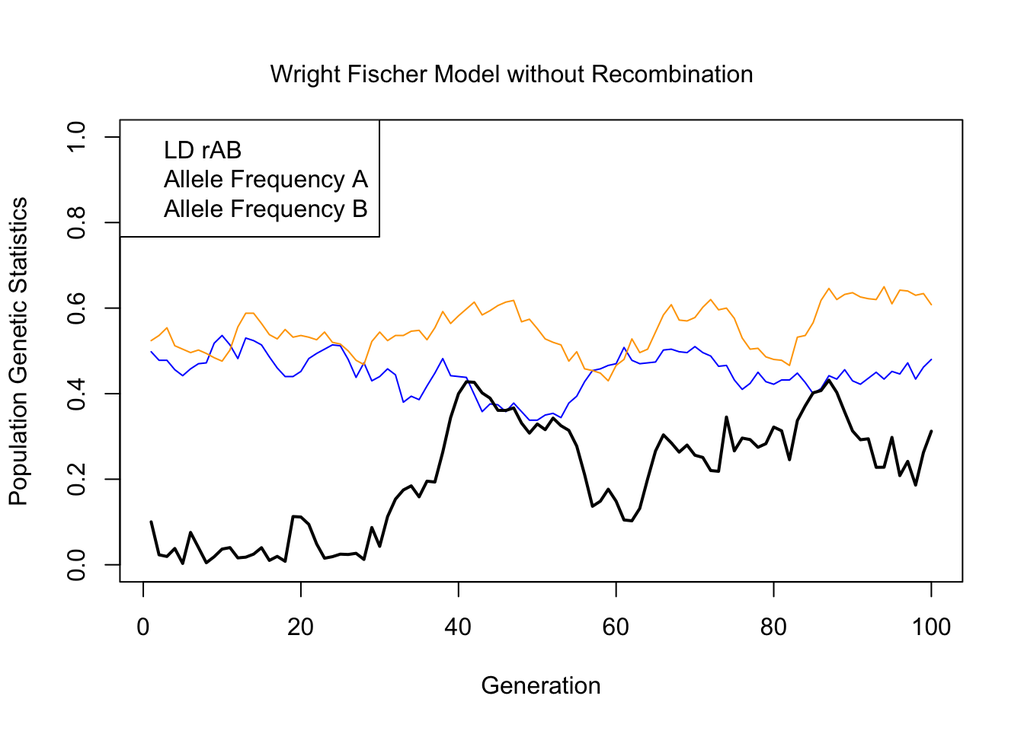

Now we plot WF with some recombination

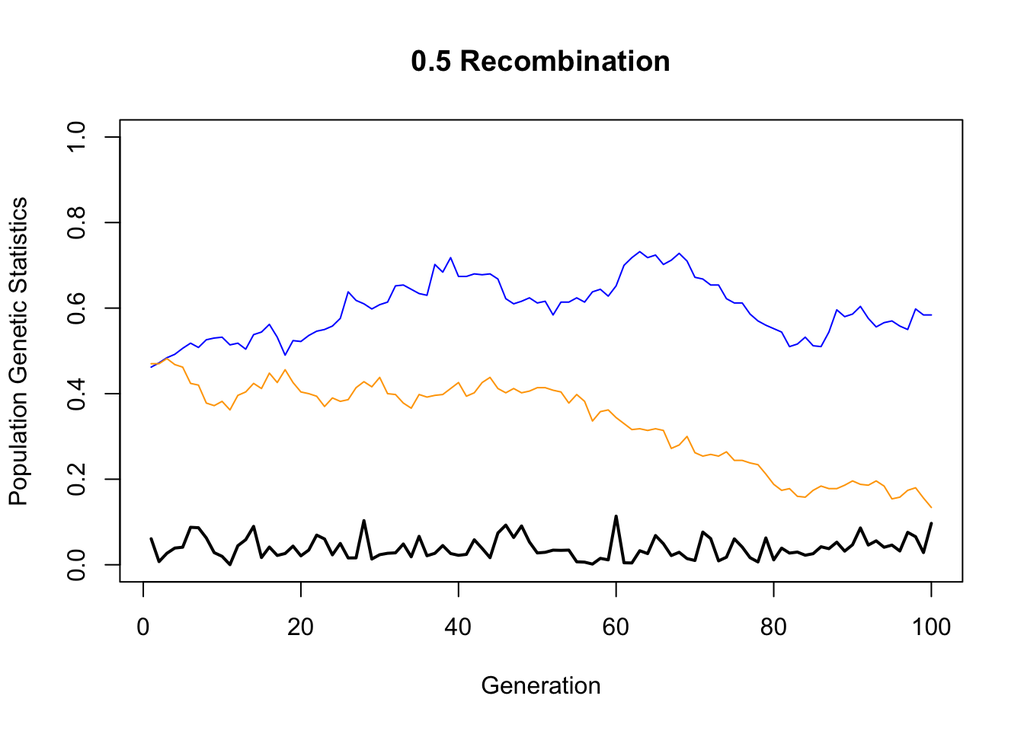

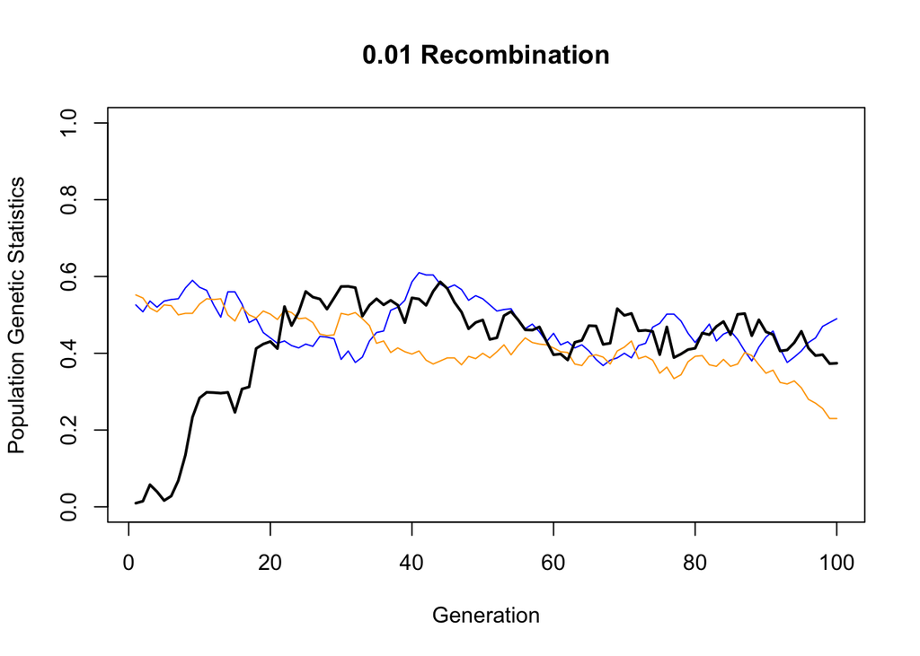

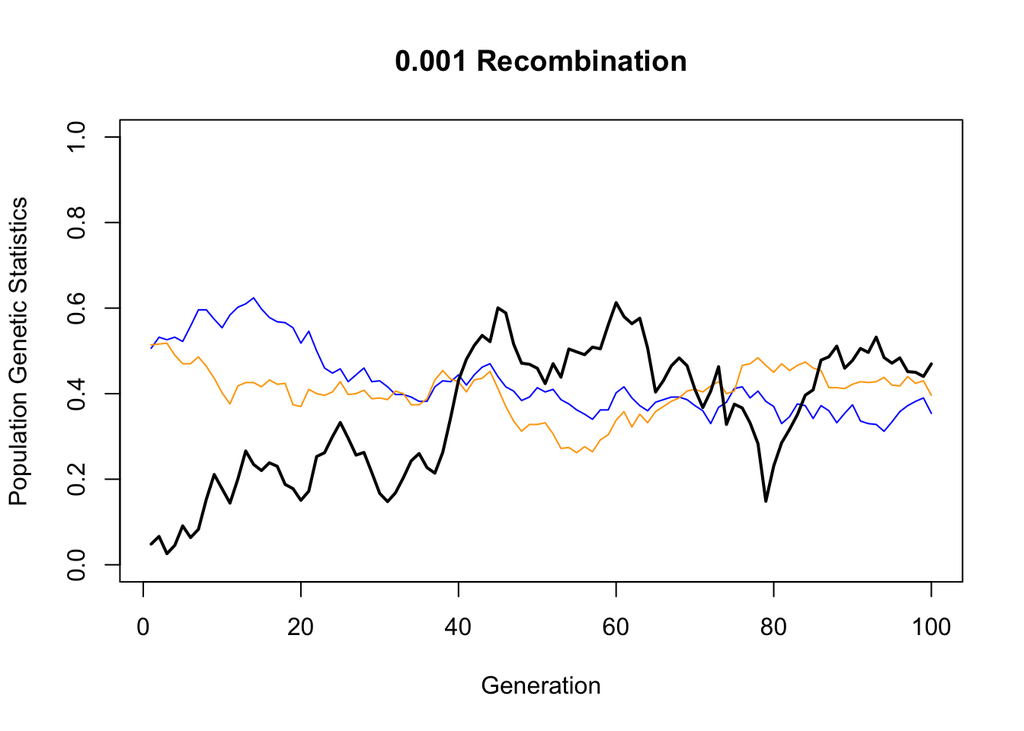

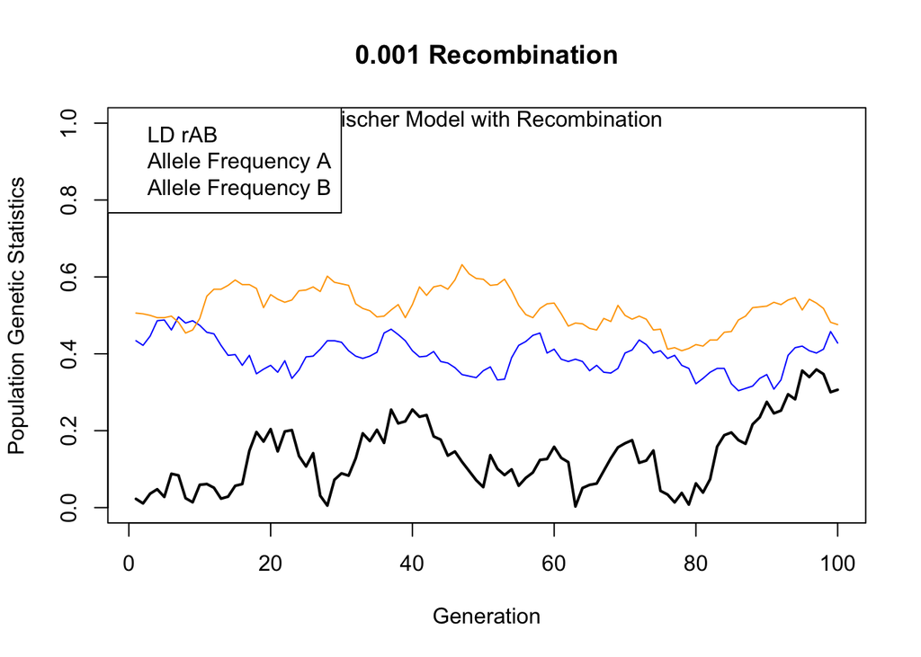

Now let’s do something with showing the stoachastic nature of the genealogy

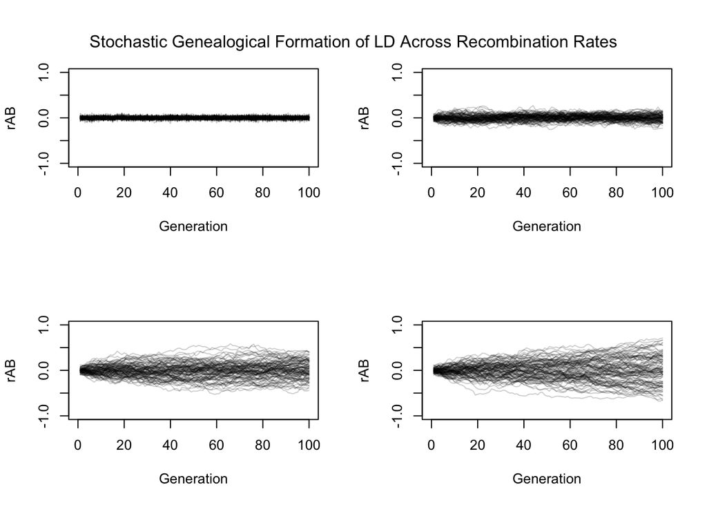